# Exploratory Data Analysis

### Q2: Of the rape victims (both forcible and attempted), what proportion are female vs male?

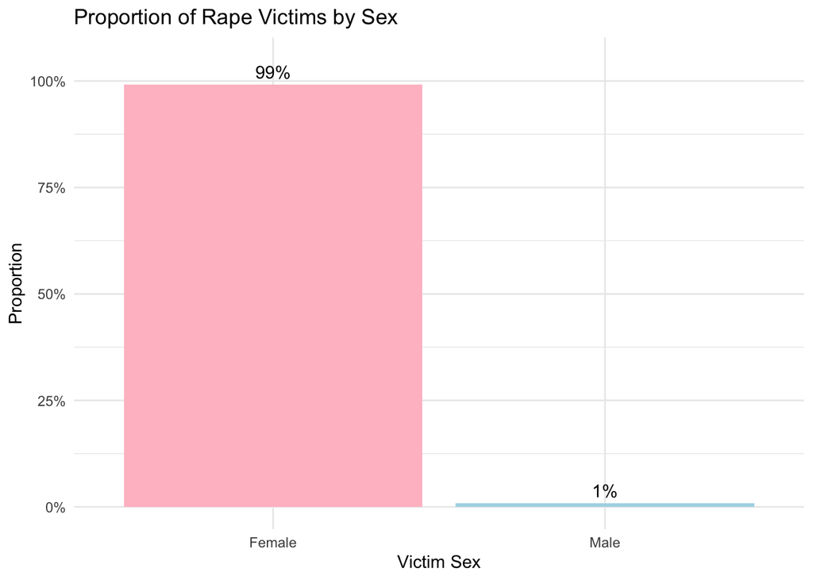

```r
rc_q2 = crime %>%
  dplyr::select(`Vict.Sex`, `Crm.Cd.Desc`) %>%
  filter(`Crm.Cd.Desc` == "RAPE, FORCIBLE" |`Crm.Cd.Desc` == "RAPE, ATTEMPTED" ) %>%
  filter(`Vict.Sex` == "F"| `Vict.Sex` == "M") %>%
  group_by(`Vict.Sex`) %>%
  summarize(count=n()) %>%
  ungroup() %>%
  mutate(prop=count/sum(count))

ggplot(rc_q2, aes(x = `Vict.Sex`, y = prop, fill = `Vict.Sex`)) +
  geom_bar(stat = "identity") +
  geom_text(aes(label = scales::percent(prop)), vjust = -0.5) +
  scale_y_continuous(labels = scales::percent, limits = c(0, 1.05)) +
  scale_fill_manual(values = c("F" = "pink", "M" = "lightblue")) +
  scale_x_discrete(labels = c("F" = "Female", "M" = "Male")) +
  labs(title = "Proportion of Rape Victims by Sex",
       x = "Victim Sex",
       y = "Proportion") +
  theme_minimal() + theme(legend.position = "none")
```

To determine the proportion of rape victims in LA that were female versus male, I filtered for just rape crimes and just female and male sexes. I used grouping, summarizing and mutating to create a proportion, then graphed it in a bar graph. I found a noticable difference between sexes as 99% of rape victims are women while only 1% are men.

# Deliverer: Leela Maitra

### Q1: How does the frequency of domestic violence cases fluctuate in Los Angeles when the LA Lakers are performing poorly (losing games), compared to when they are off-season?

```r
# breaking apart dates because it's all messed up originally
lm_results$Date <- format(as.Date(lm_results$Date, format="%a %b %d %Y"), "%m/%d/%Y")

##### ONLY RUN THIS ONCE, if you mess up reload the data and just rerun the code
lm_crime2 <- crime %>% # ONLY RUN ONCE
  separate(Date.Rptd, into = c("Date.Rptd", "Time.Rptd"), sep = " ") %>%
  separate(DATE.OCC, into = c("Date", "TIME.OCC"), sep = " ")
```

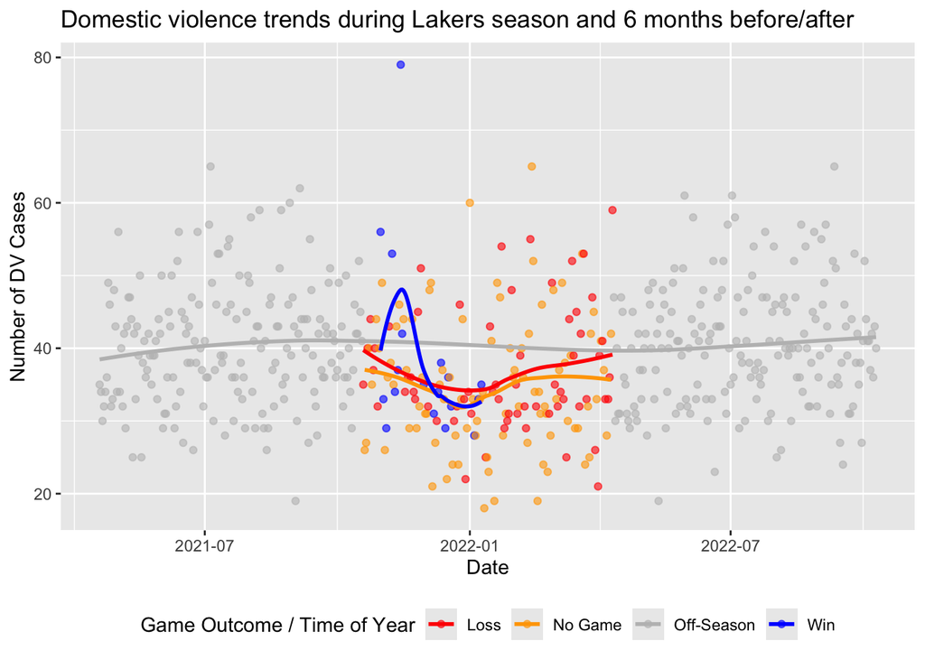

```r
#####

lm_results2 <- lm_results %>%
  rename(lm_results = X.3,  game_start = Start..ET.) %>%
  select(G, Date, game_start, Opponent, lm_results, W, L)

# the dates were characters so i made them into dates
lm_crime2$Date <- as.Date(crime$Date, format="%m/%d/%Y")
lm_results2$Date <- as.Date(lm_results$Date, format="%m/%d/%Y")

# filtering the crime data to include crimes 6 months before the Lakers' season, the season, and 6 months after
lm_crime3 <- lm_crime2 %>%
  filter(Date >= as.Date("2021-04-19") & Date <= as.Date("2022-10-10"))

# analyzing Lakers lm_results (win/loss)
lm_results3 <- lm_results2 %>%
  mutate(Period = ifelse(W > L, "Win", "Loss"))

# combining crime dataset (lm_crime3) and lm_results (lm_results3)
joined_data <- left_join(lm_crime3, lm_results3 %>% select(Date, Period), by = "Date")

# defining season start and end
season_start <- as.Date("2021-10-19")
season_end   <- as.Date("2022-04-10")

# this is me trying to analyze when the domestic violence cases happened. so if it's 6 months before or after the season, it's "off-season". if it's during the season but the DV case happened on a day without a game, it's "No Game". Then, it it's during the season and a game occurred, you have the outcome of the game (win/loss)
joined_data$Period2 <- "Off-Season"
joined_data$Period2[joined_data$Date >= season_start &
                    joined_data$Date <= season_end] <- "No Game"
joined_data$Period2[joined_data$Period == "Win"]  <- "Win"
joined_data$Period2[joined_data$Period == "Loss"] <- "Loss"

# this is me actually getting the DV cases now according to the documentation
dv_trend <- joined_data %>%
  filter(Crm.Cd %in% c(236, 626, 2000)) %>% # btw Crm.Cd is the column in crime that shows the crime code
  group_by(Date, Period2) %>%
  summarise(dv_count = n(), .groups = "drop")

# making the plot!!
ggplot(dv_trend, aes(x = Date, y = dv_count, color = Period2)) +
  geom_point(alpha = 0.6) +
  geom_smooth(method = "loess", se = FALSE) + # loess adds a smooth curve rather than a straight line like "lm"
  scale_color_manual(values = c( # without this it was all different Easter-like colors lol so i changed it manually
    "Win" = "blue",
    "Loss" = "red",
    "No Game" = "orange",
    "Off-Season" = "gray"
  )) +
  labs(title = "Domestic violence trends during Lakers season and 6 months before/after",
       x = "Date",
       y = "Number of DV Cases",
       color = "Game Outcome / Time of Year") +
  theme(legend.position = "bottom") # i did this to make the graph bigger bc it was kinda hard to read
```

```r
##### NOTES #####
# a follow-up for this could probably be running some regressions to see the actual correlation between DV cases and game win/loses. Interestingly, it seems DV cases increased when the Lakers won, so this also could be explored further.
```

### Q2: What types of crimes occur within a close proximity (~5 miles) to the UCLA campus?

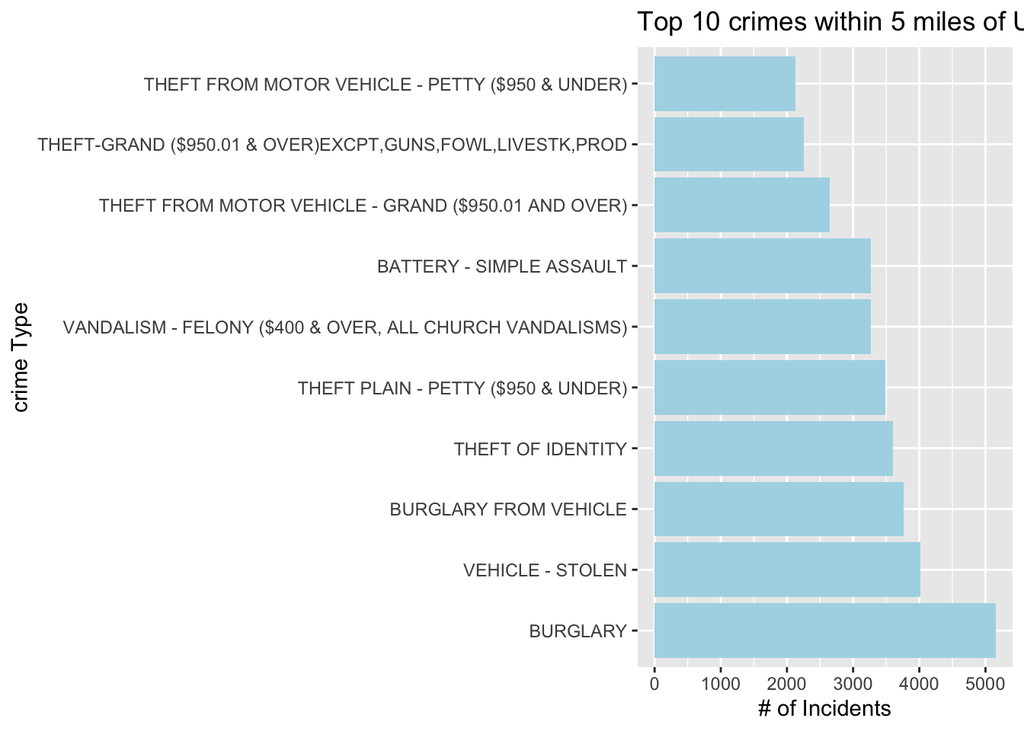

```r
# according to google, UCLA coordinates are 34.0699° N and 118.4438° W
ucla_coords <- c(-118.4438, 34.0699)

# distance from each crime to UCLA campus
lm_crime_coord <- crime %>%
  mutate(distance_meters = distHaversine(cbind(LON, LAT),  # crime location as (lon, lat), distHaversine() returns meters, so it needs to be converted to miles (i could do the other way but that seems like more work tbh)
      ucla_coords), distance_miles = distance_meters / 1609.34)

# crimes within 5 miles of UCLA campus
crime_ucla_5mi <- lm_crime_coord %>%
  filter(distance_miles <= 5)

# crime types but getting rid of categories that have less than 100 incidents or else the graph is WAY too crowded
crime_ucla_5mi_types <- crime_ucla_5mi %>%
  group_by(Crm.Cd.Desc) %>%
  summarise(count = n()) %>%
  filter(count >= 100) %>%
  arrange(desc(count))

# top 30 or else there are way too many crime categories
top_10 <- crime_ucla_5mi_types %>%
  slice_max(count, n = 10)

ggplot(top_10, aes(x = reorder(Crm.Cd.Desc, -count), y = count)) +
  geom_bar(stat = "identity", fill = "lightblue") +
  coord_flip() +
  labs(
    title = "Top 10 crimes within 5 miles of UCLA",
    x = "crime Type",
    y = "# of Incidents"
  )
```

# Follow-up Questions

### New Questions Based Off Initial Investigation

- Q1: Of the ten most common crimes in the LA suburb, which areas are most likely to experience them, and are there any noticeable trends from 2020-2024?
- Q2: How does the frequency of domestic violence cases fluctuate in Los Angeles when the LA Lakers are playing, compared to when they are off-season?
- Q3: How do a victim’s demographics — specifically descent, sex, and age — influence the frequency with which crimes are committed against them, and how do these same factors affect the likelihood that a case is resolved (i.e., classified as “Investigation Complete” vs. not)?
- Q4: Which types of crimes have the longest and shortest reporting delays, and how do these delays vary based on the victim’s sex?

### Investigation of Follow-up Questions

Our group decided to investigate Q1 and Q3 in further detail.

How do a victim’s demographics — specifically descent, sex, and age — influence the frequency with which crimes are committed against them, and how do these same factors affect the likelihood that a case is resolved (i.e., classified as “Investigation Complete” vs. not)? :

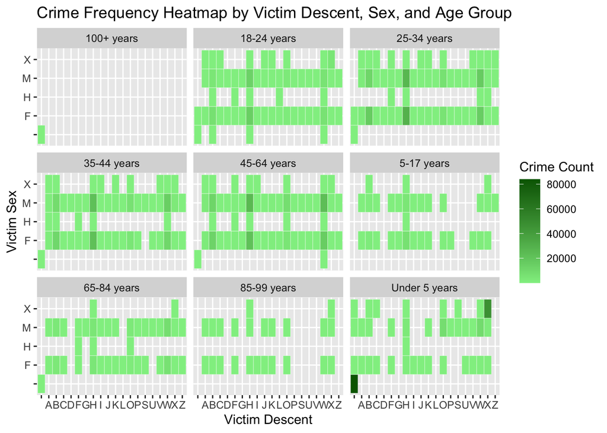

```r
crime_cleaned <- crime %>%
  mutate(IC_Status = ifelse(Status == "IC", 1, 0), Vict.Age = as.numeric(Vict.Age), Vict.Descent = as.factor(Vict.Descent), Vict.Sex = as.factor(Vict.Sex)) %>%
  mutate(Age_Group = ifelse(Vict.Age < 5, "Under 5 years",
                     ifelse(Vict.Age <= 17, "5-17 years",
                     ifelse(Vict.Age <= 24, "18-24 years",
                     ifelse(Vict.Age <= 34, "25-34 years",
                     ifelse(Vict.Age <= 44, "35-44 years",
                     ifelse(Vict.Age <= 64, "45-64 years",
                     ifelse(Vict.Age <= 84, "65-84 years",
                     ifelse(Vict.Age <= 99, "85-99 years", "100+ years")))))))))
ic_summary <- crime_cleaned %>%
  group_by(Vict.Descent, Vict.Sex, Age_Group) %>%
  summarise(IC_Rate = mean(IC_Status), Count = n(), .groups = 'drop')

ggplot(ic_summary, aes(x=Vict.Descent, y=Vict.Sex, fill=Count)) +
  geom_tile(color="white") +
  facet_wrap(~Age_Group) +
  scale_fill_gradient(low="lightgreen", high="darkgreen", name="Crime Count") +
  labs(title="Crime Frequency Heatmap by Victim Descent, Sex, and Age Group",
       x="Victim Descent", y="Victim Sex")
```

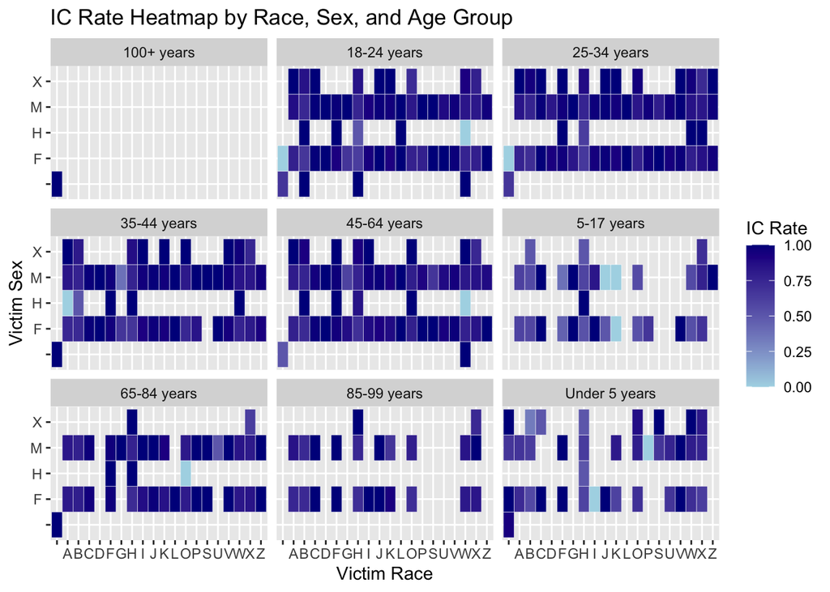

```r
ggplot(ic_summary, aes(x=Vict.Descent, y=Vict.Sex, fill=IC_Rate)) +
  geom_tile(color="white") +
  facet_wrap(~Age_Group) +
  scale_fill_gradient(low="lightblue", high="darkblue", name="IC Rate") +
  labs(title="IC Rate Heatmap by Race, Sex, and Age Group",
       x="Victim Race", y="Victim Sex")
```

```r
JD_Crime2.0.0 <- crime%>%
  rename(ReportDate="Date.Rptd",OccuranceDate="DATE.OCC",TimeOccured="TIME.OCC",CrimeType="Crm.Cd.Desc")%>%
  mutate(ReportDate=str_replace(ReportDate," 0:00",""),
         OccuranceDate=str_replace(OccuranceDate," 0:00",""))%>%
  select(c(1,3,10,27:28))


JD_Crime2.0.1 <- JD_Crime2.0.0%>%
    separate(OccuranceDate, into = c("OccuranceMonth", "OccuranceDay", "OccuranceYear"), sep = "/")%>%
  mutate(OccuranceYear = substr(OccuranceYear, 1, 4))

top_10_crimes <- JD_Crime2.0.1%>%
  group_by(CrimeType)%>%
  summarise(count=n())%>%
  arrange(desc(count))%>%
  slice_head(n=10)

JD_Crime3.0.0 <- JD_Crime2.0.1%>%
  group_by(CrimeType) %>%
  mutate(count = n()) %>%
  mutate(CrimeType = recode(CrimeType, "VEHICLE - STOLEN" = "Stolen Vehicle", "BATTERY - SIMPLE ASSAULT" = "Battery Assault", "VANDALISM - FELONY ($400 & OVER, ALL CHURCH VANDALISMS)" = "Felony Vandalism","BURGLARY"="Burglary","BURGLARY FROM VEHICLE"="Burglary From Vehicle","ASSAULT WITH DEADLY WEAPON, AGGRAVATED ASSAULT"="Aggravated Assault","INTIMATE PARTNER - SIMPLE ASSAULT"="Assault - Intimate Partner", "THEFT PLAIN - PETTY ($950 & UNDER)"="Petty Theft","THEFT FROM MOTOR VEHICLE - PETTY ($950 & UNDER)"="Petty Theft - In Vehicle","THEFT OF IDENTITY"="Identity Theft","VANDALISM - MISDEAMEANOR ($399 OR UNDER)"="Misdeameanor Vandalism","ROBBERY"="Robbery","THEFT-GRAND ($950.01 & OVER)EXCPT,GUNS,FOWL,LIVESTK,PROD"="Grand-Theft","THEFT FROM MOTOR VEHICLE - GRAND ($950.01 AND OVER)"="Grand Theft Auto","CRIMINAL THREATS - NO WEAPON DISPLAYED"="Criminal Threats"))%>%
  filter(count >= 41300) %>%
  ungroup()

unique(JD_Crime3.0.0$CrimeType)
```

```
## [1] "Stolen Vehicle"  "Identity Theft"  "Battery Assault"
```